# Laguna Merin 2019

División Calidad y Evaluación Ambiental

15 marzo, 2021

# Gráficos y análisis de datos básicos

En los informes anuales primero se presenta por separando cada subcuenca/zona/cauce; en el caso de laguna Merín, esa división se hace para cada río o arroyo y luego se integra esa iformación con gráficos que comparan las cuencas entre sí.

## Análisis de datos

Consideraciones:

- Las estaciones deben ordenarse desde las nacientes hasta la desembocadura
- el PT y PO4 deben estar en la misma unidad; en el caso del IET es necesario el PT en μg/L
- NT y todos los demás, en general están en mg/L

Los cáclulos que deben realizarse antes de empezar son:

- Se calcula NH3 a partir de NH4 según Canadian Water Quality Guidelines for the Protection of Aquatic Life ([ver Ammonia](http://ceqg-rcqe.ccme.ca/download/en/141)):

$$NH_3 (\mu g) = \frac{1000 \times NH_4 (mg)}{(1+10^{(-pH+0.0901821+\frac{2729.92}{T(º C)+273.15} )})}$$

- El valor de IET, se calcula solamente para las estaciones lóticas, con la siguiente ecuación:

$$IET = 10 \times (6-\frac{0.42-0.36 \times ln(\overline{PT (\mu g/L)})}{ln(2)})-20$$

- El valor $\overline{PT (\mu g/L)}$ representa la media geométrica anual (no confundir con la media aritmética) de los valores del Fósforo Total (en microgramos por litro) obtenidos para cada estación, en las distintas campañas.

El IET se normaliza en una escala de 0 a 100, dividida en seis rangos de estados tróficos, desde la Ultraoligotrofía a la Hipereutrofía. Se considera 1 decimal después de la coma para pasar de un estado a otro (por ejemplo: 59,1 corresponde a un estado eutrófico). Los seis estados se indican con colores.

| Clasificación | Criterio |
| --- | --- |
| Ultraoligotrófico | IET ≤ 47 |
| Oligotrófico | 47 < IET ≤ 52 |
| Mesotrófico | 52 < IET ≤ 59 |
| Eutrófico | 59 < IET ≤ 63 |
| Supereutrófico | 63 < IET ≤ 67 |
| Hipereutrófico | IET > 67 |

La interpretación del IET y el valor final a publicar en el informe debe ser realizado con cautela y tomando en cuenta la globalidad del ecosistema.

## Gráficos

### Fisicoquímicos y nutrientes

Para una fase exploratoria se grafican todos los nutrientes, pero luego debe evaluarse cuidadosamente el número de valores cuantificados que hay en cada caso y volver a pensar si corresponde graficar o si es mejor colocar los valores en una tabla.

#### Olimar

##### Fisicoquímico

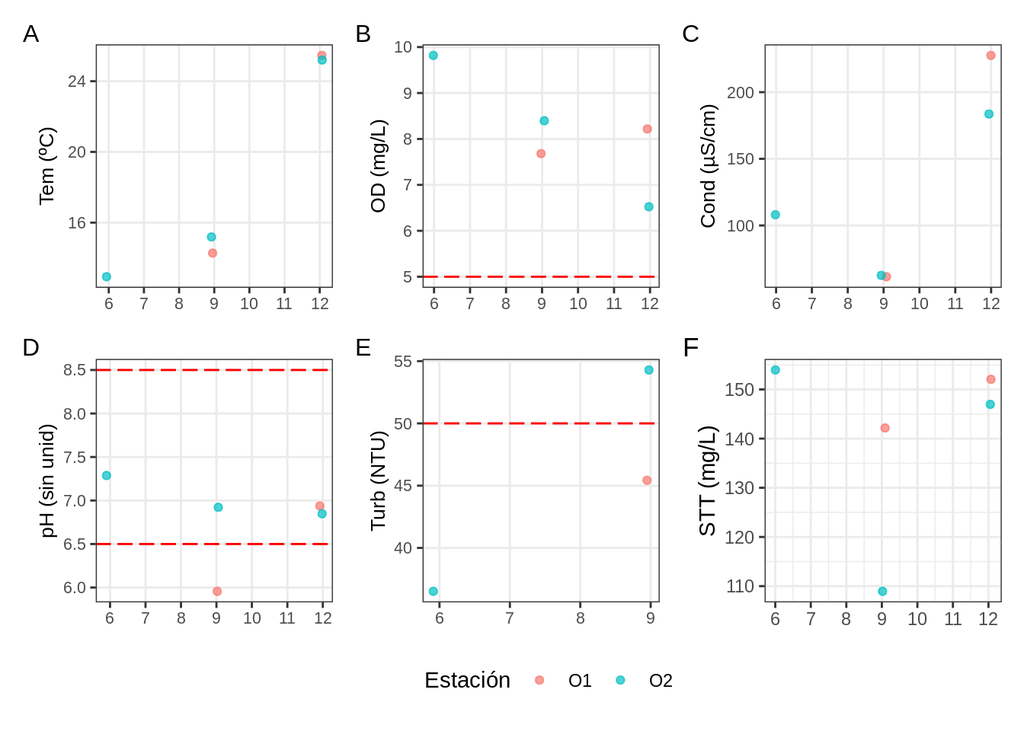

Fisicoquímicos, Río Olimar

##### Nutrientes

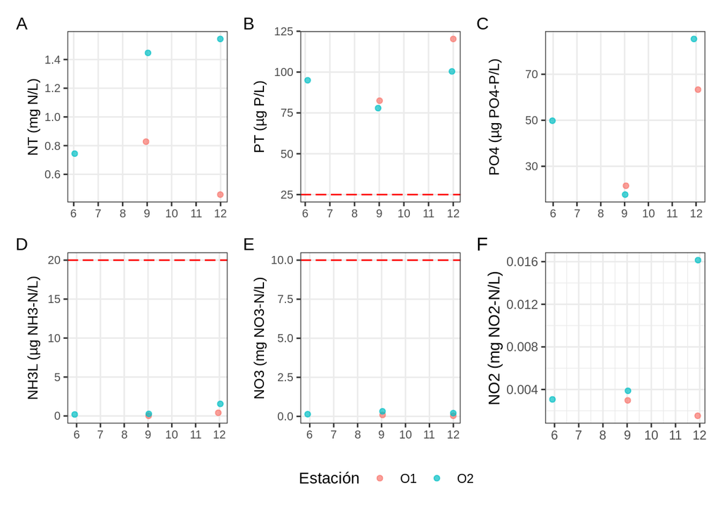

Nutrientes, Río Olimar

Comparación entre estaciones

Los puntos representan la media o promedio y las líneas +/- desvío estándar

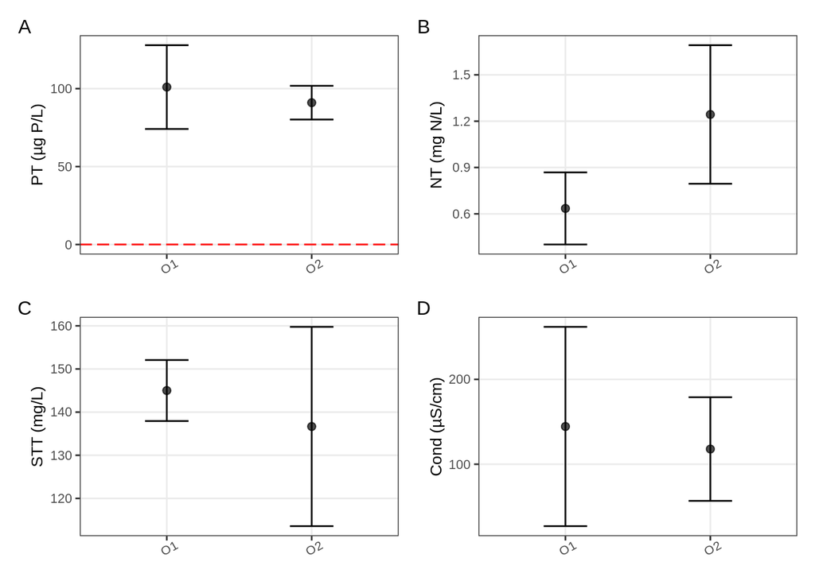

Comparación entre estaciones, Río Olimar

#### Cebollatí

##### Fisicoquímicos

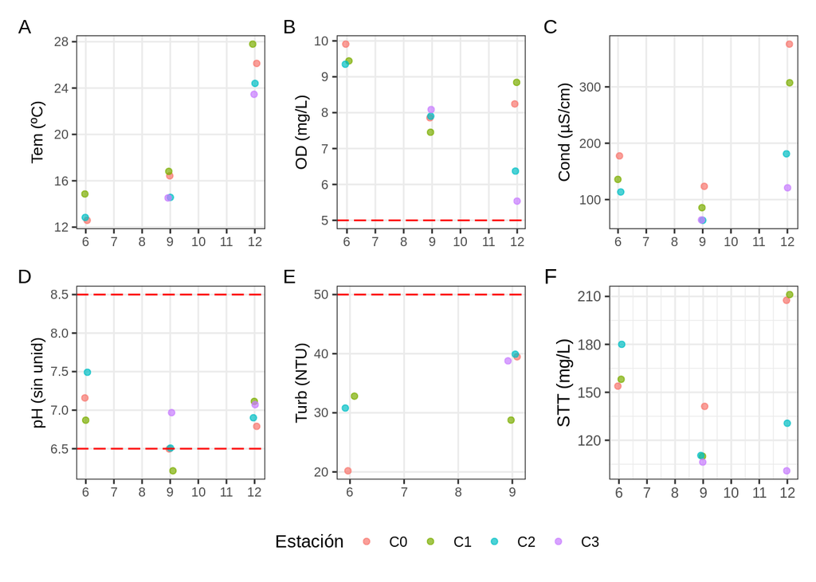

##### Nutrientes

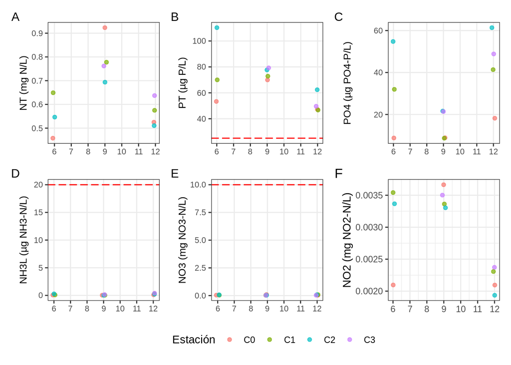

##### Comparación entre estaciones

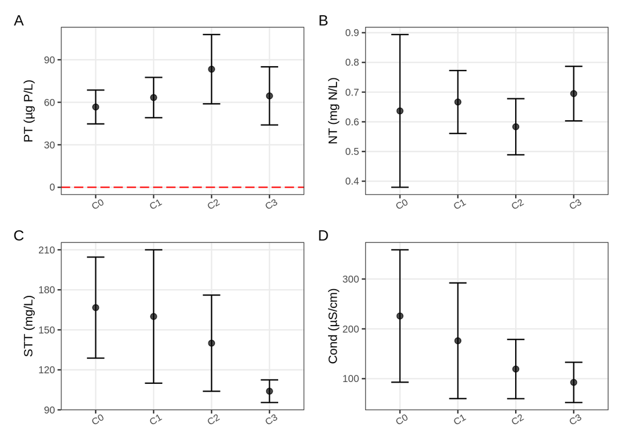

### Comparación entre las subcuencas

#### Fisicoquímicos y nutrientes

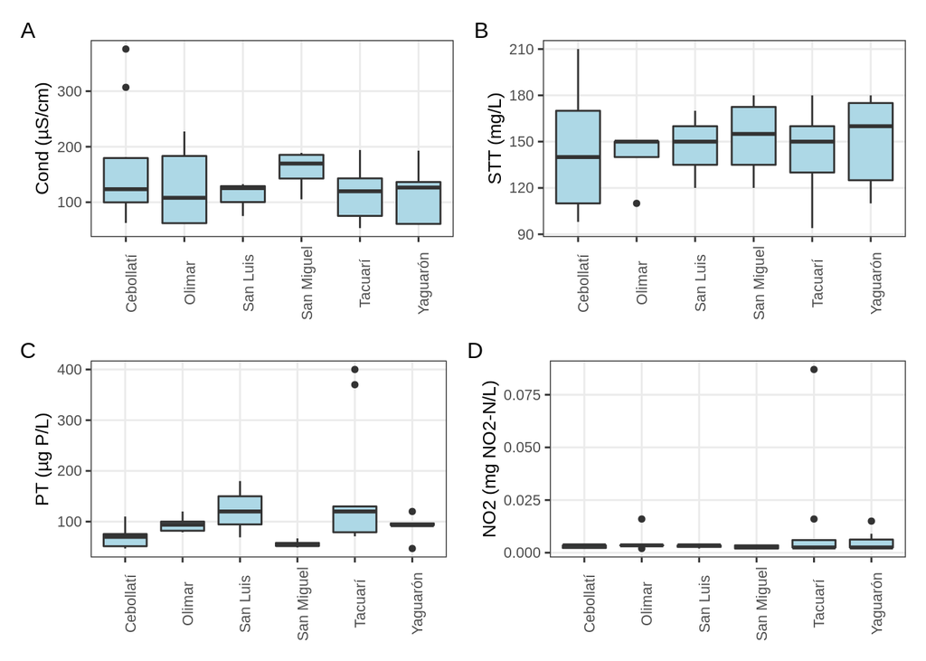

### Cloforila-A

En este caso hay un solo valor de clorofila por fecha de muestreo. Las líneas entrecortadas naranja y roja indican los niveles de alerta 1 y 2 de la OMS respectivamente.

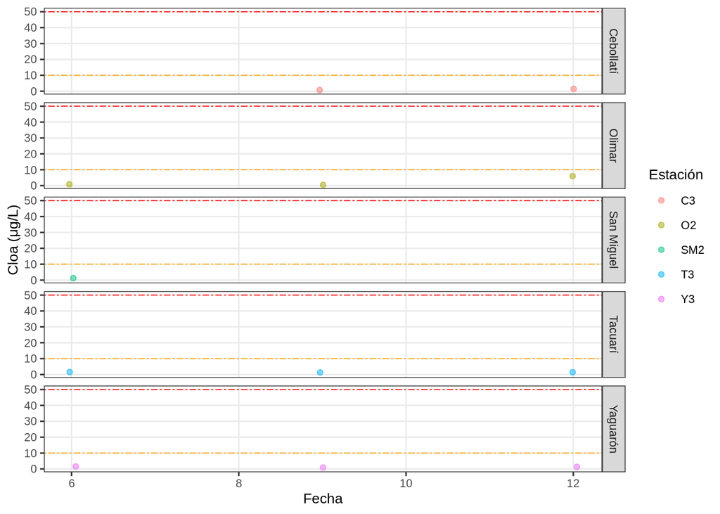

### Coliformes

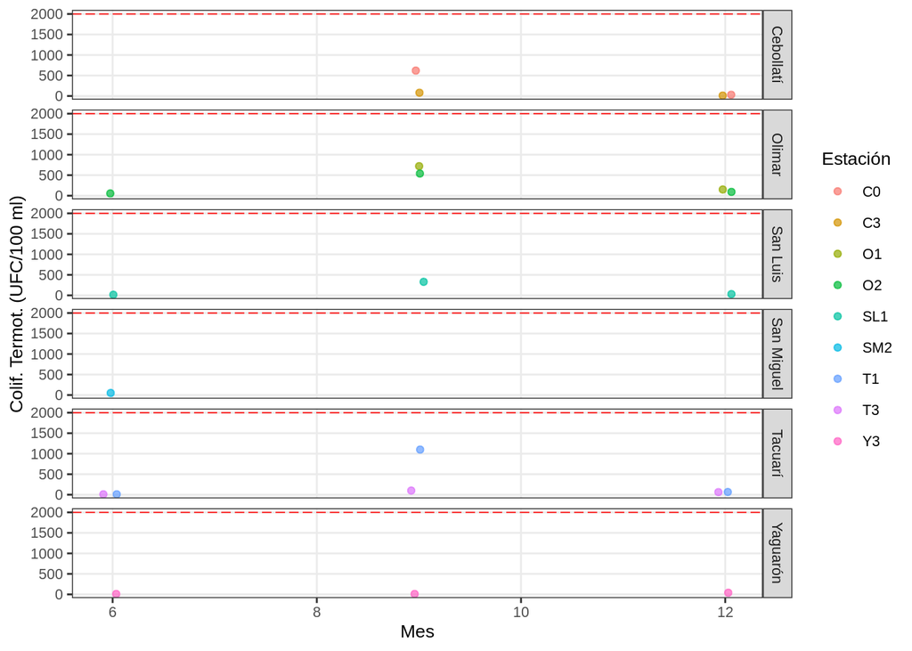

### IET

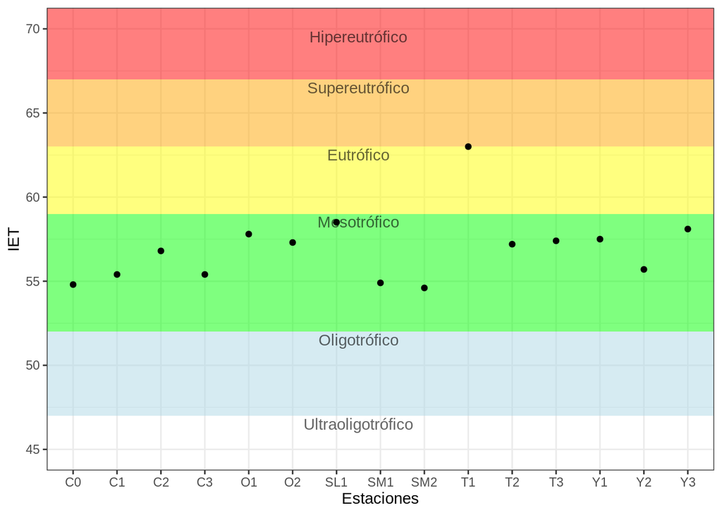

| Estación | IET | Clasificación |
| --- | --- | --- |
| C0 | 54.8 | Mesotrófico |
| C1 | 55.4 | Mesotrófico |
| C2 | 56.8 | Mesotrófico |
| C3 | 55.4 | Mesotrófico |
| O1 | 57.8 | Mesotrófico |
| O2 | 57.3 | Mesotrófico |
| SL1 | 58.5 | Mesotrófico |
| SM1 | 54.9 | Mesotrófico |
| SM2 | 54.6 | Mesotrófico |
| T1 | 63.0 | Eutrófico |
| T2 | 57.2 | Mesotrófico |
| T3 | 57.4 | Mesotrófico |
| Y1 | 57.5 | Mesotrófico |
| Y2 | 55.7 | Mesotrófico |
| Y3 | 58.1 | Mesotrófico |